# Chapter 15

jim108@gmx.net

7/3/2020

```r
library(rethinking)
library(gtools)
```

## 15E1.

Given: Oceanic tools model:

$T_i \sim Poisson(\mu_i)$

$log\mu_i = \alpha + \beta log P_i$

$\alpha \sim Normal(0, 1.5)$

$\beta \sim Normal(0, 1)$.

Want: Add measured error on the log population size of each society.

Sol.:

$P_{OBS,i} =$ “log population of island $i$”, $P_{SE,i} =$ “log standard error of island $i$”.

$T_i \sim Poisson(\mu_i)$

$log\mu_i = \alpha + \beta P_{TRUE,i}$

$\alpha \sim Normal(0, 1.5)$

$\beta \sim Normal(0, 1)$

$P_{OBS,i} \sim Log-Normal(exp(P_{TRUE,i}), exp(P_{SE,i}))$

$P_{TRUE,i} \sim Log-Normal(0, exp(4))$.

## 15E2.

Given: Oceanic tools model:

$T_i \sim Poisson(\mu_i)$

$log\mu_i = \alpha + \beta log P_i$

$\alpha \sim Normal(0, 1.5)$

$\beta \sim Normal(0, 1)$.

Want: Add imputation of missing values for log population.

Sol.:

$P´_{i} =$ “log population of island $i$”, $P´_{i} =$ “log standard error of island $i$”.

$T_i \sim Poisson(\mu_i)$

$log\mu_i = \alpha + \beta P´_{i}$

$\alpha \sim Normal(0, 1.5)$

$\beta \sim Normal(0, 1)$

$P´_{i} \sim Log-Normal(exp(0), exp(4))$.

## 15M1.

Given: Mathematical form of the imputation model in chapter.

$K_i ∼ Normal(\mu_i , \sigma)$

$\mu_i = \alpha + \beta_B B_i + \beta M log M_i$

$B_i ∼ Normal(\nu, \sigma_B )$

$\alpha \sim Normal(0, 0.5)$

$\beta_B \sim Normal(0, 0.5)$

$\beta_M \sim Normal(0, 0.5)$

$\sigma \sim Exponential(1)$

$\nu \sim Normal(0.5, 1)$

$\sigma_B \sim Exponential(1)$.

Want: What is being assumed about how missing values were generated?

- The missing brain sizes are normal distributed with a expected value $\nu$, which is choosen from $\nu \sim Normal(0.5, 1)$ and a standard deviation, which is choosen from $\sigma_B \sim Exponential(1)$.

## 15M2.

Given: Primate milk data and model with missing cases.

Want: Model with imputed cases. Compare WAIC values.

Sol.:

```r
data(milk)
d <- milk
d$neocortex.prop <- d$neocortex.perc / 100
d$logmass <- log(d$mass)
nrow(d)
```

```
## [1] 29
```

```r
dcc <- d[complete.cases(d),]
nrow(dcc)
```

```
## [1] 17
```

```r
dat_listcc <- list(
    K = standardize( dcc$kcal.per.g ),
    B = standardize( dcc$neocortex.prop ),
    M = standardize( dcc$logmass ) )
```

```r
set.seed(1)
m15M2a <- ulam(
    alist(
        K ~ dnorm( mu , sigma ),
        mu <- a + bB*B + bM*M,
        c(a) ~ dnorm( 0 , 0.5 ),
        c(bB,bM) ~ dnorm( 0, 0.5 ),
        sigma ~ dexp( 1 )
    ) , data=dat_listcc , chains=4 , cores=4, log_lik = TRUE )
```

```
## Trying to compile a simple C file
```

```r
dat_list <- list(
    K = standardize( d$kcal.per.g ),
    B = standardize( d$neocortex.prop ),
    M = standardize( d$logmass ) )
```

```r
m15M2b <- ulam(
    alist(
        K ~ dnorm( mu , sigma ),
        mu <- a + bB*B + bM*M,
        B ~ dnorm( nu , sigma_B ),
        c(a,nu) ~ dnorm( 0 , 0.5 ),
        c(bB,bM) ~ dnorm( 0, 0.5 ),
        sigma_B ~ dexp( 1 ),
        sigma ~ dexp( 1 )
    ) , data=dat_list , chains=4 , cores=4, log_lik = TRUE )
```

```
## Found 12 NA values in B and attempting imputation.
```

```
## Trying to compile a simple C file
```

```r
coeftab(m15M2a, m15M2b)
```

```
##              m15M2a  m15M2b
## a               0.00    0.03
## bM             -0.67   -0.54
## bB              0.57    0.49
## sigma           0.83    0.85
## nu                NA   -0.05
## sigma_B           NA    1.01
## B_impute[1]       NA   -0.56
## B_impute[2]       NA   -0.67
## B_impute[3]       NA   -0.71
## B_impute[4]       NA   -0.29
## B_impute[5]       NA    0.46
## B_impute[6]       NA   -0.17
## B_impute[7]       NA    0.18
## B_impute[8]       NA    0.28
## B_impute[9]       NA    0.54
## B_impute[10]      NA   -0.43
## B_impute[11]      NA    -0.3
## B_impute[12]      NA    0.14
## nobs              17      29
```

```r
compare(m15M2a, m15M2b)
```

```
##            WAIC       SE    dWAIC      dSE    pWAIC       weight
## m15M2a 43.45215 4.624333  0.00000       NA 2.462630 1.000000e+00
## m15M2b 77.57511 5.715078 34.12297 7.465368 5.011957 3.893066e-08
```

- According to WAIC, the model with imputed values predicts new values much worse.

## 15M3.

Given: Divorce data measurement error model.

Want: Double the standard errors. Explain impact on inference.

Sol.:

```r
data(WaffleDivorce)
d <- WaffleDivorce
```

```r
dlista <- list(
    D_obs = standardize( d$Divorce ),
    D_sd = d$Divorce.SE / sd( d$Divorce ),
    M = standardize( d$Marriage ),
    A = standardize( d$MedianAgeMarriage ),
    N = nrow(d)
)
dlistb <- list(
    D_obs = standardize( d$Divorce ),
    D_sd = 2*d$Divorce.SE / sd( d$Divorce ),
    M = standardize( d$Marriage ),
    A = standardize( d$MedianAgeMarriage ),
    N = nrow(d)
)
```

```r
l15M3 <- alist(
        D_obs ~ dnorm( D_true , D_sd ),
        vector[N]:D_true ~ dnorm( mu , sigma ),
        mu <- a + bA*A + bM*M,
        a ~ dnorm(0,0.2),
        bA ~ dnorm(0,0.5),
        bM ~ dnorm(0,0.5),
        sigma ~ dexp(1)
    )
```

```r
set.seed(1)
m15M3a <- ulam(l15M3, data=dlista , chains=4 , cores=4, iter=1e4 )
```

```
## Trying to compile a simple C file
```

```r
set.seed(1)
m15M3b <- ulam(l15M3, data=dlistb , chains=4 , cores=4, iter=1e4 )
```

```
## recompiling to avoid crashing R session
```

```
## Trying to compile a simple C file
```

```r
precis(m15M3b)
```

```
## 50 vector or matrix parameters hidden. Use depth=2 to show them.
```

```
##             mean         sd        5.5%       94.5%     n_eff    Rhat4
## a     -0.1104731 0.09575721 -0.27009838  0.03690591 506.00944 1.016655
## bA    -0.6381922 0.15899475 -0.91173805 -0.39345285 338.49656 1.029620
## bM     0.1924841 0.17679874 -0.10156483  0.48054224 622.86771 1.020311
## sigma  0.1418938 0.10939208  0.01836092  0.34773412  61.55092 1.063769
```

```r
precis(m15M3a)
```

```
## 50 vector or matrix parameters hidden. Use depth=2 to show them.
```

```
##              mean         sd       5.5%       94.5%     n_eff    Rhat4
## a     -0.05403050 0.09583604 -0.2047551  0.09862606 13988.133 1.000184
## bA    -0.61540145 0.15738974 -0.8658605 -0.36489754 10463.344 1.000168
## bM     0.05135424 0.16557515 -0.2165721  0.31203120  9333.673 1.000259
## sigma  0.58474200 0.10634504  0.4243556  0.76191838  5857.562 1.001354
```

```r
precis(m15M3b)
```

```
## 50 vector or matrix parameters hidden. Use depth=2 to show them.
```

```
##             mean         sd        5.5%       94.5%     n_eff    Rhat4
## a     -0.1104731 0.09575721 -0.27009838  0.03690591 506.00944 1.016655
## bA    -0.6381922 0.15899475 -0.91173805 -0.39345285 338.49656 1.029620
## bM     0.1924841 0.17679874 -0.10156483  0.48054224 622.86771 1.020311
## sigma  0.1418938 0.10939208  0.01836092  0.34773412  61.55092 1.063769
```

- The number of effective samples is a lot worse, making the result with double the standard error not trustworthy.
- The model with double the standard error infers a slight influence of marriage rate on divorce, but with an equally high standard error.

## 15H1.

Given: Elefant data.

Want: (a) Fit Poisson model predictiong `MATINGS` with `AGE` as a predictor. (b) Fit Poisson model predictiong `MATINGS` with `AGE` as a predictor with a standard error of +- 5 years. Compare.

Sol.:

```r
data("elephants")
d <- elephants
summary(d)
```

```
##       AGE           MATINGS
##  Min.   :27.00   Min.   :0.000
##  1st Qu.:29.00   1st Qu.:1.000
##  Median :34.00   Median :2.000
##  Mean   :35.85   Mean   :2.683
##  3rd Qu.:42.00   3rd Qu.:3.000
##  Max.   :52.00   Max.   :9.000
```

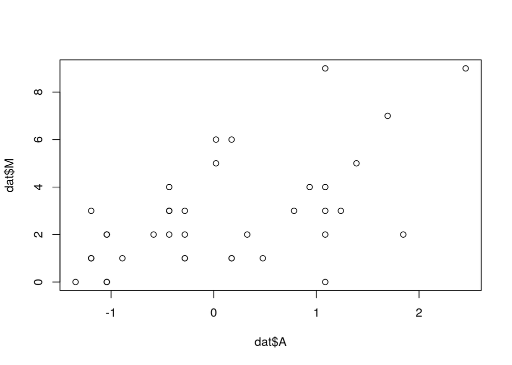

```r
dat <- list(
    M = d$MATINGS,
    A = standardize(d$AGE))

plot(dat$M~dat$A)
```

```r
set.seed(1)
m15H1a <- ulam(
    alist(
        M ~ dpois( lambda ),
        log(lambda) <- a + b*A,
        a ~ dnorm(log(3)  , 0.1 ),
        b ~ dnorm(log(2)  , 0.1 )
    ), data=dat , chains=4 , cores=4, log_lik=TRUE )
```

```
## Trying to compile a simple C file
```

```r
#Sermon on priors.
#Expected:
#A=0: M=3 or pop. shrinks, thus a:=log(3)
#A=1: M=6, thus b:=log(2)
#=> A=-1: log(3) - log(2) = log(3/2) = 0.4

set.seed(1)
m15H1a.prior <- extract.prior( m15H1a)
```

```
## Trying to compile a simple C file
```

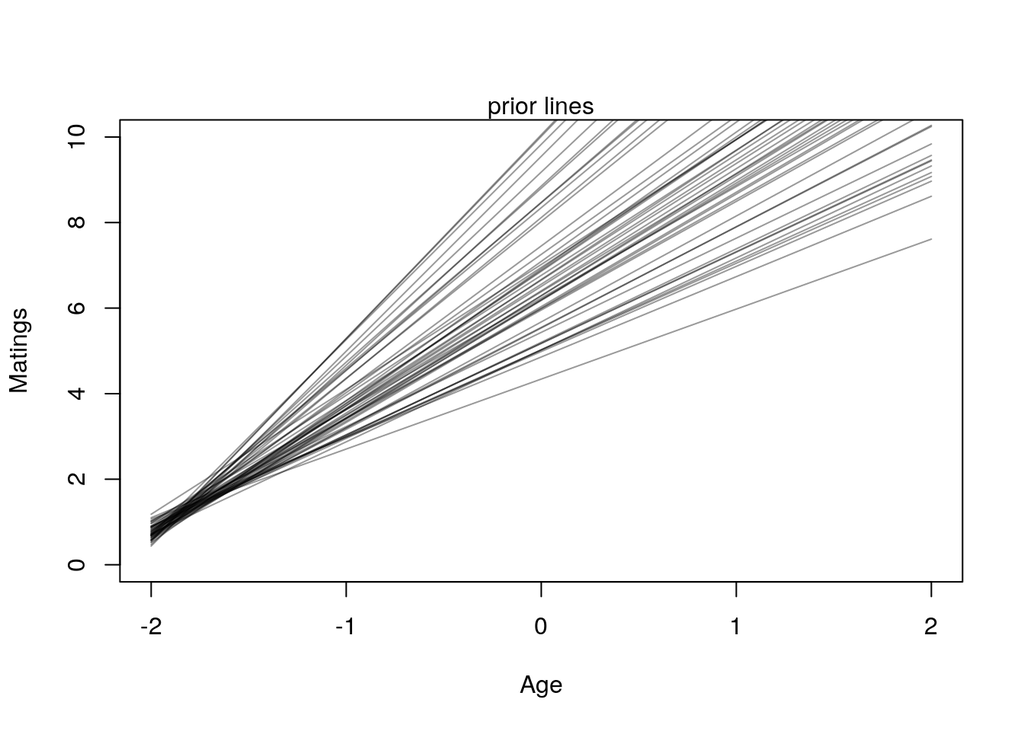

```r
mu <- link( m15H1a , post=m15H1a.prior , data=list( A=c(-2,2) ) )
plot( NULL , xlim=c(-2,2) , ylim=c(0,10), xlab="Age", ylab="Matings" )
for ( i in 1:50 ) lines( c(-2,2) , mu[i,] , col=col.alpha("black",0.4) )
mtext("prior lines")
```

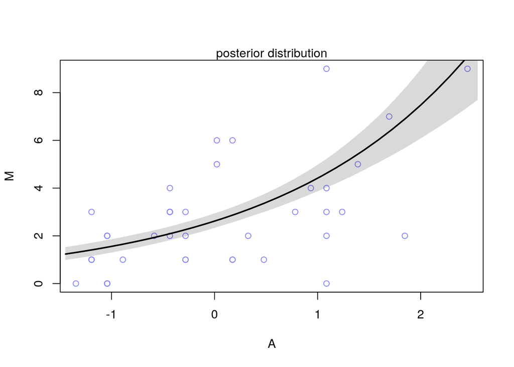

```r
A_seq <- seq( from=min(dat$A)-0.1 , to=max(dat$A)+0.1 , length.out=30 )
mu <- link( m15H1a , data=list(A=A_seq) )
mu.mean <- apply( mu , 2, mean )
mu.PI <- apply( mu , 2 , PI )

# plot it all
plot( M ~ A , data=dat , col=rangi2 )
lines( A_seq , mu.mean , lwd=2 )
shade( mu.PI , A_seq )
mtext("posterior distribution")
```

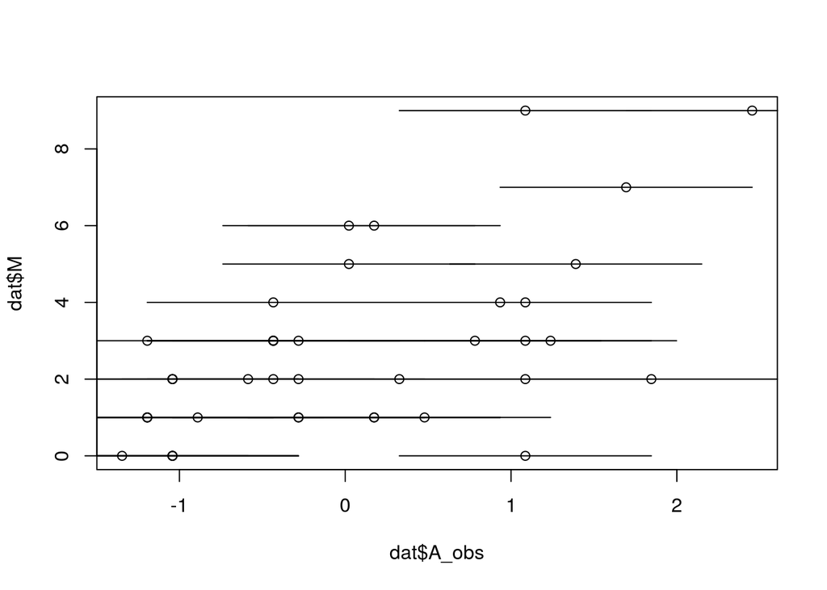

```r
dat <- list(
    M = d$MATINGS,
    A_obs = standardize(d$AGE),
    A_sd = rep(5/sd(d$AGE),nrow(d)),
    N = nrow(d))

plot(dat$M~dat$A_obs)

for ( i in 1:nrow(d) ) {
    ci <- dat$A_obs[i] + c(-1,1)*dat$A_sd[i]
    x <- dat$M[i]
    lines( ci, c(x,x) )
}
```

```r
set.seed(1)
m15H1b <- ulam(
    alist(
        M ~ dpois( lambda ),
        log(lambda) <- a + b*A_true[i],
        A_obs ~ dnorm( A_true , A_sd ),
        vector[N]:A_true ~ dnorm( 0 , 1 ),
        a ~ dnorm(log(3)  , 0.1 ),
        b ~ dnorm(log(2)  , 0.1 )
    ), data=dat , chains=4 , cores=4, log_lik=TRUE )
```

```
## Trying to compile a simple C file
```

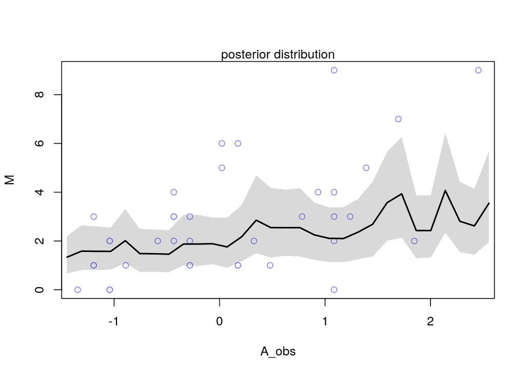

```r
A_seq <- seq( from=min(dat$A_obs)-0.1 , to=max(dat$A_obs)+0.1 , length.out=30 )
mu <- link( m15H1b , data=list(A_obs=A_seq) )
mu.mean <- apply( mu , 2, mean )
mu.PI <- apply( mu , 2 , PI )

# plot it all
plot( M ~ A_obs , data=dat , col=rangi2 )
lines( A_seq , mu.mean , lwd=2 )
shade( mu.PI , A_seq )
mtext("posterior distribution")
```

```r
precis(m15H1a)
```

```
##        mean         sd      5.5%     94.5%    n_eff     Rhat4
## a 0.9590430 0.07278067 0.8468478 1.0769518 1119.005 0.9993344
## b 0.5226477 0.06231569 0.4201240 0.6225875 1226.292 1.0015380
```

```r
precis(m15H1b)
```

```
## 41 vector or matrix parameters hidden. Use depth=2 to show them.
```

```
##        mean         sd      5.5%     94.5%    n_eff     Rhat4
## a 0.9786904 0.07602194 0.8601995 1.0974668 3195.844 0.9991795
## b 0.6517678 0.08371458 0.5181709 0.7882952 2503.545 0.9992527
```

- The models predict differend mean functions. Although the intercepts are the same, the model with noise has a slightly higher slope.
- According to the plot, the model without noise is a smooth accending curve.
- According to the plot, the model with noise predicted mean function is not smooth and only slightly assending.

## 15H2.

Given: 15H1.

Want: Increase standard error until the slope reaches zero.

Sol.:

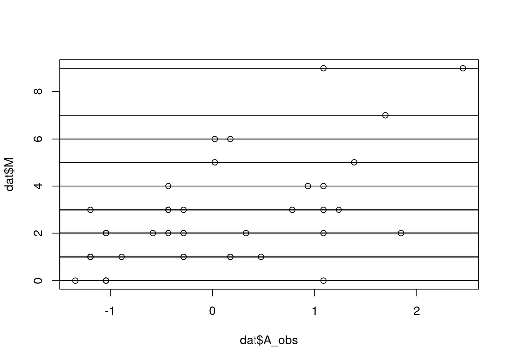

```r
dat <- list(
    M = d$MATINGS,
    A_obs = standardize(d$AGE),
    A_sd = rep(4,nrow(d)),
    N = nrow(d))

plot(dat$M~dat$A_obs)

for ( i in 1:nrow(d) ) {
    ci <- dat$A_obs[i] + c(-1,1)*dat$A_sd[i]
    x <- dat$M[i]
    lines( ci, c(x,x) )
}
```

```r
set.seed(1)
m15H1c <- ulam(
    alist(
        M ~ dpois( lambda ),
        log(lambda) <- a + b*A_true[i],
        A_obs ~ dnorm( A_true , A_sd ),
        vector[N]:A_true ~ dnorm( 0 , 1 ),
        a ~ dnorm(log(3)  , 0.1 ),
        b ~ dnorm(log(2)  , 0.1 )
    ), data=dat , chains=4 , cores=4, log_lik=TRUE )
```

```
## recompiling to avoid crashing R session
```

```
## Trying to compile a simple C file
```

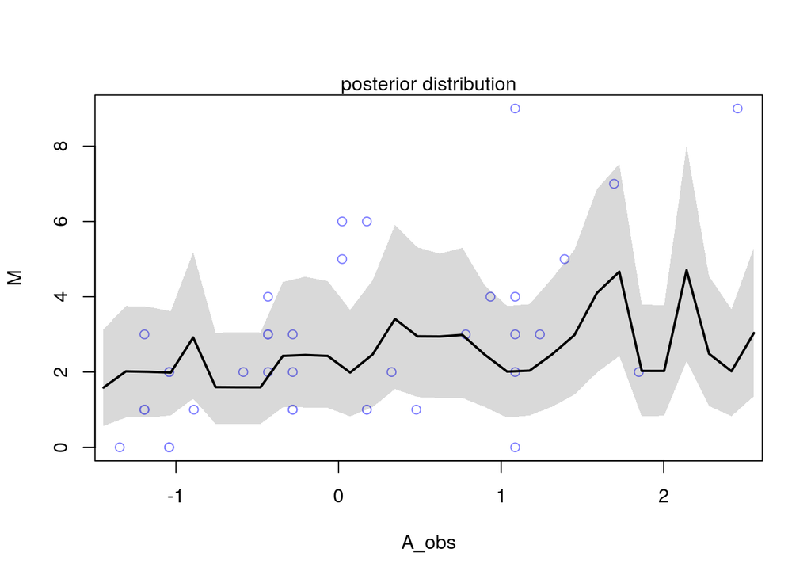

```r
A_seq <- seq( from=min(dat$A_obs)-0.1 , to=max(dat$A_obs)+0.1 , length.out=30 )
mu <- link( m15H1c , data=list(A_obs=A_seq) )
mu.mean <- apply( mu , 2, mean )
mu.PI <- apply( mu , 2 , PI )

# plot it all
plot( M ~ A_obs , data=dat , col=rangi2 )
lines( A_seq , mu.mean , lwd=2 )
shade( mu.PI , A_seq )
mtext("posterior distribution")
```

```r
precis(m15H1c)
```

```
## 41 vector or matrix parameters hidden. Use depth=2 to show them.
```

```
##        mean         sd      5.5%     94.5%    n_eff    Rhat4
## a 0.9970284 0.08262783 0.8718181 1.1348458 2544.851 1.000004
## b 0.6397317 0.08341716 0.5070086 0.7768824 2024.797 0.999957
```

- Even a standard deviation of 4 does not reduce the slope.
- The model without noise has the lowest slope.

## 15H3.

Given:

```r
set.seed(100)
x <- c( rnorm(10) , NA )
y <- c( rnorm(10,x) , 100 )
d <- data.frame(x,y)
```

Want: (a) Regression on `x` with only the complete cases. (b) Regression on `x` with imputed values. Use model:

$y_i \sim Normal(\mu_i,\sigma)$

$\mu_i = \alpha + \beta x_i$

$x_i \sim Normal(0,1)$

$\alpha,\beta \sim Normal(0,100)$

$\sigma \sim HalfCauchy(0,1)$

Sol.:

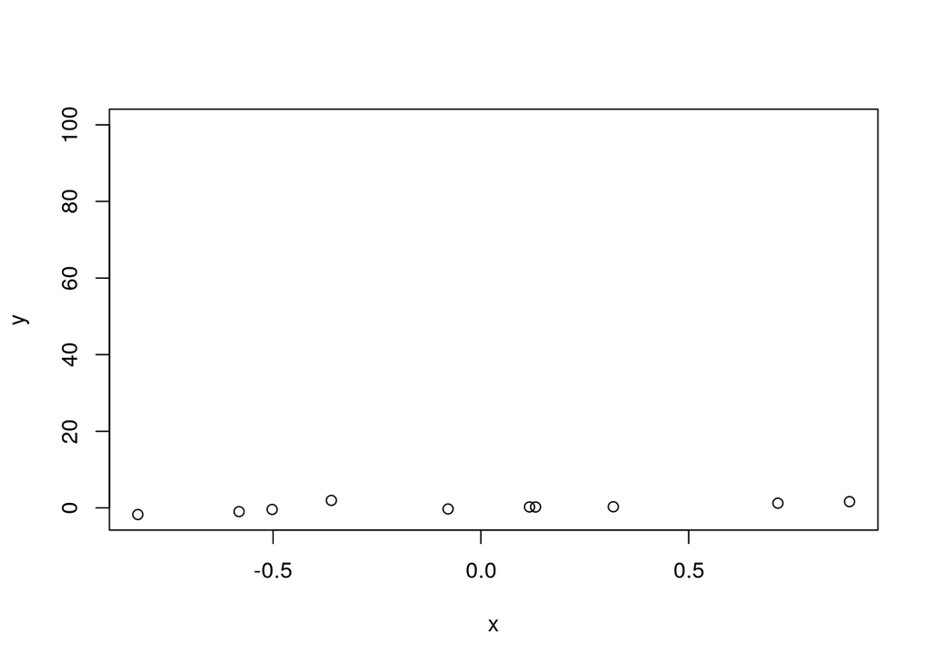

```r
plot(y~x)
```

```r
dcc <- d[complete.cases(d),]
```

```r
set.seed(1)
m15H3a <- ulam(
    alist(
        y ~ dnorm( mu, sigma ),
        mu <- a + b*x,
        c(a,b) ~ dnorm(0, 100),
        sigma ~ dhalfcauchy(0,1)
    ), data=dcc , chains=4 , cores=4)
```

```
## Trying to compile a simple C file
```

```r
precis(m15H3a)
```

```
##            mean        sd       5.5%     94.5%    n_eff     Rhat4
## b     1.4273979 0.5801114  0.5349801 2.3606216 1287.438 0.9997058
## a     0.2382234 0.3171516 -0.2366178 0.7665715 1350.808 1.0026950
## sigma 0.9649086 0.2525984  0.6430899 1.3954868 1046.546 1.0014366
```

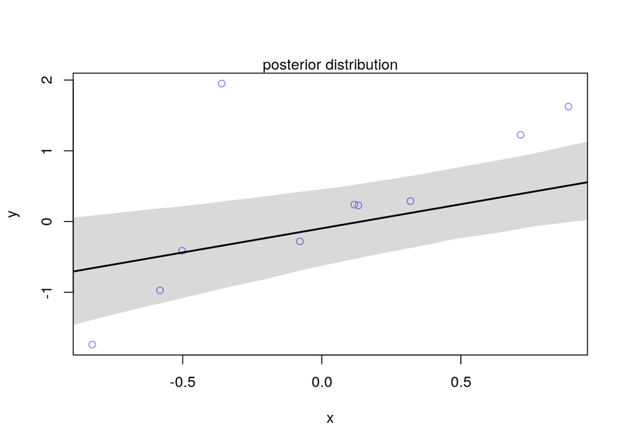

```r
x_seq <- seq( from=min(dcc$x)-0.1 , to=max(dcc$x)+0.1 ,
              length.out=30 )
mu <- link( m15H3a , data=list(x=x_seq) )
mu.mean <- apply( mu , 2, mean )
mu.PI <- apply( mu , 2 , PI )

# plot it all
plot( y ~ x , data=dcc , col=rangi2 )
lines( A_seq , mu.mean , lwd=2 )
shade( mu.PI , A_seq )
mtext("posterior distribution")
```

```r
set.seed(1)
m15H3b <- ulam(
    alist(
        y ~ dnorm( mu, sigma ),
        mu <- a + b*x,
        x ~ dnorm(0,1),
        c(a,b) ~ dnorm(0, 100),
        sigma ~ dhalfcauchy(0,1)
    ), data=d , chains=4 , cores=4, iter=1e4)
```

```
## Found 1 NA values in x and attempting imputation.
```

```
## Trying to compile a simple C file
```

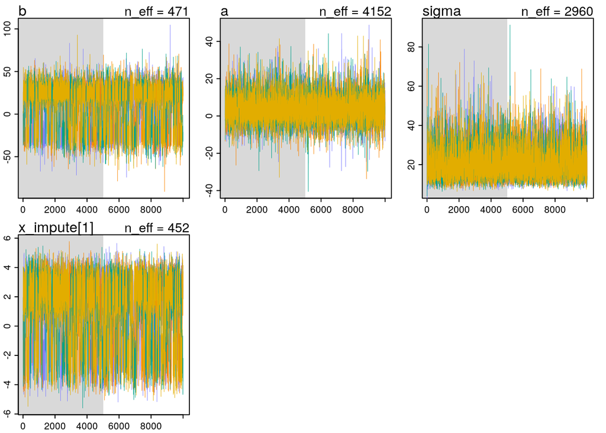

```r
traceplot(m15H3b)
```

```r
precis(m15H3b, depth = 2)
```

```
##                   mean        sd       5.5%     94.5%     n_eff     Rhat4
## b            9.4481350 25.131073 -32.670718 37.379502  471.2379 1.0067371
## a            4.0423692  6.952497  -6.050244 15.356420 4152.0631 0.9999808
## sigma       20.1998102  7.440869  11.125054 33.789794 2959.6865 1.0001072
## x_impute[1]  0.9137988  2.356333  -3.121244  3.699062  451.5924 1.0055455
```

```r
x_seq <- seq( from=min(d$x,na.rm = T)-0.1 , to=max(d$x,na.rm = T)+0.1 ,
              length.out=30 )
#mu <- link( m15H3b , data=list(x=x_seq) )
#Error in merge_missing(x_missidx, to_vector(x), x_impute) : could not find function "merge_missing"
#https://github.com/rmcelreath/rethinking/issues/193
```

- Because of a bug the `m15H3b` could not be plotted.
- The last y value (100) is very high in comparison to the other values. If it is used by imputing the x value it changes the prediction.

## 15H4.

Given: Eight-sided spinner.

```r
values <- 1:8
frequencies <- c(18,19,22, NA, NA, 19, 20, 22)
d <- data.frame(values, frequencies)
```

- None of the values is twice as likely as any other.

Want: Is the spinner fair. Use a Dirichlet distribution to capture this prior belief. Plot the joint posterior distribution of 4s and 5s.

Sol.:

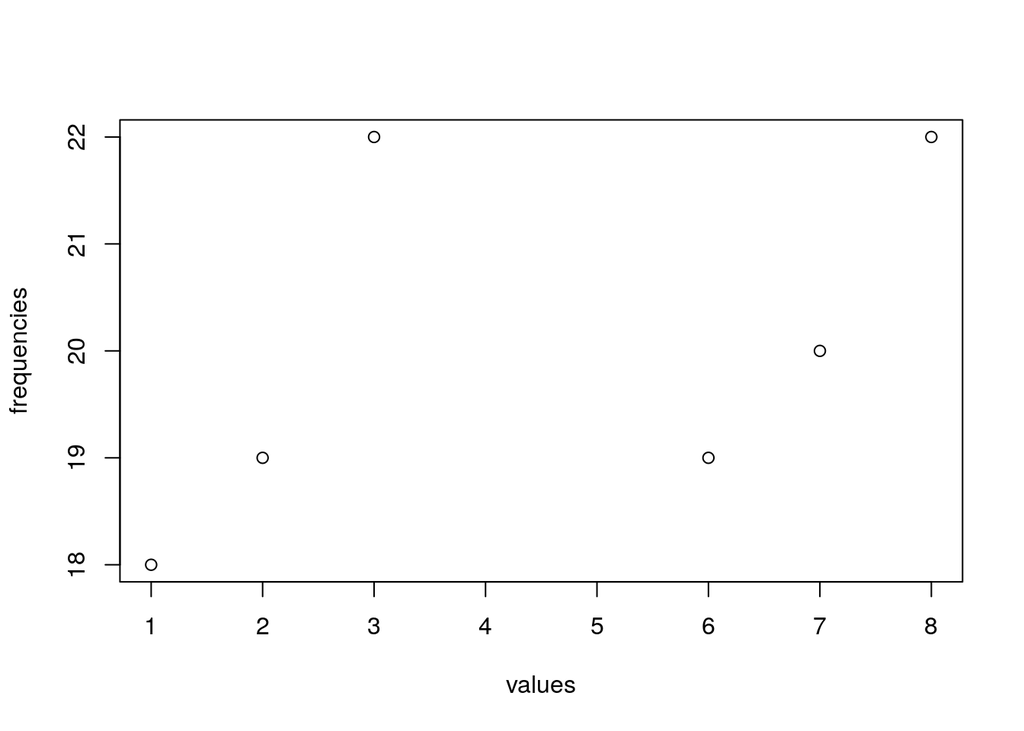

```r
plot(frequencies~values)
```

```r
dcc <- d[complete.cases(d),]
N_obs <- nrow(dcc)
dat <- list(
    V = rep(1:N_obs, dcc$frequencies),
    alpha = rep( 2 , N_obs ),
    N = N_obs)
```

```r
set.seed(1)
m15H4 <- ulam(
    alist(
        V ~ categorical(p),
        simplex[N]:p ~ dirichlet( alpha )
    ), data=dat , chains=4, cores=4 )
```

```
## Trying to compile a simple C file
```

```r
pr <- precis(m15H4, depth = 2)
max(sapply(pr$mean - 1/N_obs, abs))
```

```
## [1] 0.01581141
```

- It is unclear if splitting up the values was the right choice and how they can be aggregated in Stan again.
- Omitting the missing cases, a 6-valued spinner has a deviation from a fair spinner of only 1.6 percent at maximum.